# Growing Incarceration Inequities based on Urbanicity

Teerth Mehta

2022-11-27

## Introduction

Often rural areas tend to get overlooked in American discourse in regards to the crisis of mass incarceration. Yet, recently a large proportion of the growth in this crisis comes from smaller sized counties (i.e. rural and small counties) where criminal justice resources such as diversion programs are far and few between. Furthermore, because law enforcement resources such as judges are also stretched in rural areas, one would see other aspects of mass incarceration in rural areas manifest as a high amount of pretrial incarcerations, or incarcerations which await trials. As such, this project is a practice in the *Analysis* stage of the process of challenging power in Data Feminism, where I use data to expose inequities in the structure of criminal justice between rural and urban areas in the country in a more clear manner than may have previously been seen. Given this information, the direct stakeholders of this report may be policy-makers at various levels of government and advocates of criminal justice reform who push for policies that aim to mitigate and eventually end mass incarceration. Thus, they may use this data to show and inform future policy positions such that they take into account the large impact that rural incarceration has been recently playing in the overall crisis and hopefully decrease the future impact on rural areas of this awful crisis. In turn, the indirect stakeholders are those who have been impacted or touched by the criminal justice system, specifically those who live or are incarcerated in more sparsely populated areas, counties, and states and those who will be impacted by the policies that this report may inspire. To this end, I answer some questions such as: how do increases in jail capacity correlate with pretrial incarceration and - Where do these incarcerations happen to be geographically? - What trends do predominantly rural states experience in incarceration over time? - What type of urbanicity experiences the highest incarceration rates? - What types of counties have fueled the mass incarceration crisis the most since 1970?

## Data Summary

Given that this report is about disparities in mass incarceration over different types of urbanicities, I began by looking at the difference between jail capacities and jail populations over the entire urbanicities. It was clear that small and medium sized counties had the greatest difference with a difference of 48588 open prisoner spots and the smallest difference was seen in suburban counties had the smallest difference with a difference of 38565 open prisoner spots. This larger difference in much less populated counties shows us that there is an unnecessarily large reliance on incarceration as a tool of justice, and this shows the pattern of inequity that there are a lack of alternatives to incarceration in these counties. This inequity is further shown through the fact that the average incarceration rate in rural counties is higher at 693 and in urban counties it is lower at 324. We see that for some reason rural communities tend to incarcerate their own residents at higher rates than urban communities and any other communities for that matter. Finally, we see the same trends in pretrial incarceration, where smaller counties tend to put more people in pretrial incarceration. This may be due to, again, the fact that smaller counties may not have the resources to keep people out incarceration. As such, smaller and mid-sized counties have the most pretrial incarcerations at 168522 prisoners and suburban counties which may have the more resources to have pretrial incarcerations at 99935 prisoners.

## Growth of the U.S. Prison Population

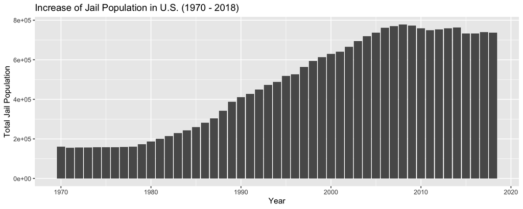

Increase of Jail Population in U.S.: Presenting the trend of the incarcerated population in the US from 1970 to 2018 through a bar chart.

One can see the clear trend of increasing overall incarcerations since 1970 and up till 2009. Since 2009, the trend of overall incarceration has plateaued and has began to decrease by almost 50,000 prisoners into 2018. Furthermore, one can also see that the greatest increase in incarceration began in 1980 and ending around 2000.

## Growth of Prison Population by State

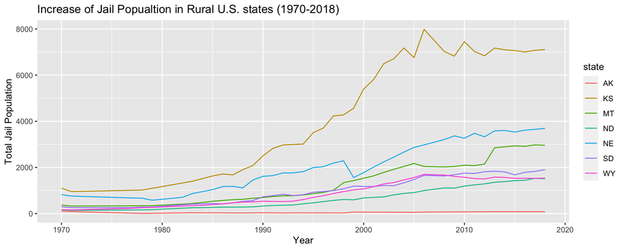

Increase of Jail Population in Rural U.S. states: Presenting the trend of the incarcerated population in the 7 most rural U.S. states from 1970 to 2018 through a line chart.

## Inequities Present in Population Growth of Counties and their Prisons

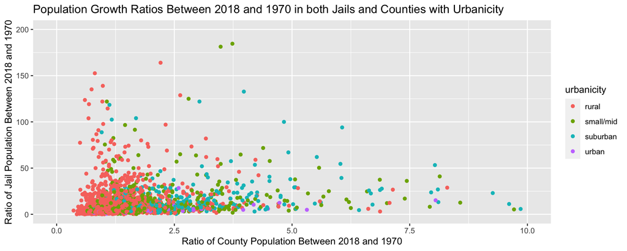

Inequities Present in Population Growth of Counties and their Prisons: Using ratios to quantify growth and plot in scatter plots the relationship between growth in regular populations and incarcerated populations in different urbanities

This scatterplot shows how the population growth of different counties and the prison population growth of the prisons on those different counties between 1970 and 2018, as expressed in ratios of populations in 2018 to populations in 1970, are related. Each dot is a county, and the color of each dot is in reference to its urbanicity. The clear pattern that comes across is the fact that though rural counties have not seen much overall growth in population, their prison populations have had the most growth since 1970. This shows us that rural counties have produced the greatest increase in mass incarceration since 1970. One question this graph answers is: which urbanicity has fueled the most growth in mass incarceration since 1970? The concise answer to that question is rural urbanicities and this is particularly troubling because there is not an equal increase in general county populations.

## Geographical Inequities Present in Pretrial Populations and the Increase in Jail Capacity by State

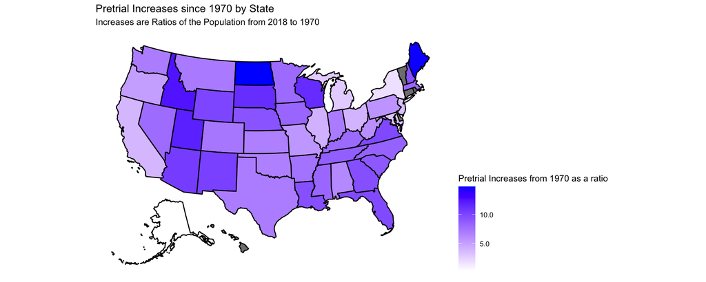

Geographical Inequities Present in Pretrial Populations and the Increase in Jail Capacity by State: Using ratios to quantify growth of pretrial incarceration, jail capacity increases, and geographical location

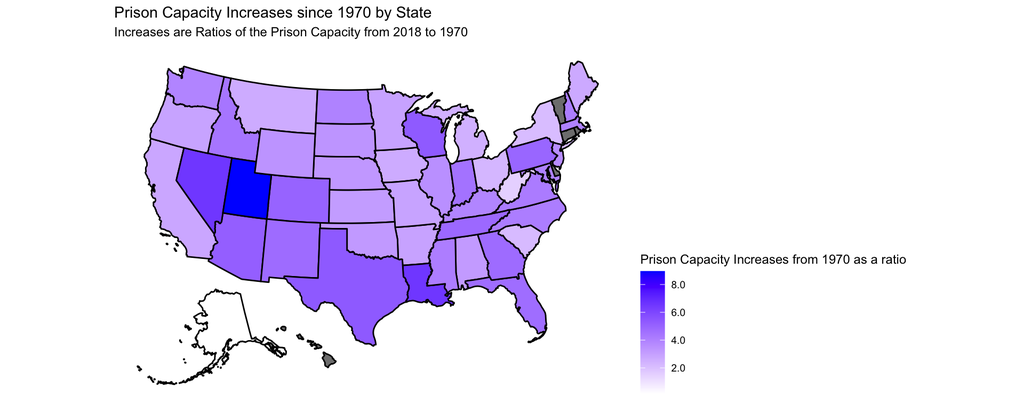

Geographical Inequities Present in Pretrial Populations and the Increase in Jail Capacity by State: Using ratios to quantify growth of pretrial incarceration, jail capacity increases, and geographical location

These two maps show us the disparities between the increase in jail capacity and pretrial incarcerations. What one can see is that often rural states in the Midwest (i.e. North Dakota, Wisconsin) tend to see the greatest increase in pretrial incarcerations since 1970 while increase in jail capacities do not necessarily fully follow the same pattern and in many cases are related in the opposite direction. What these trends show us is that criminal justice reforms and resources are not equitably distributed across the United States, where rural areas suffer the brunt of this inequity. This is evidenced by a lack of jail capacity in rural areas compared to an increased number of pretrial incarcerations as a symptom of a lack of pretrial diversions or criminal justice staff to evaluate cases right away. One question that can be answered by this graph is: what are the geographical distributions of criminal justice resources in the US? The concise answer to this question is that rural Midwestern states have seen a greater growth in pretrial incarcerations in response to a slower rate of increase in criminal justice resources, one symptom being a lower increase in jail capacity.